# Grid search de modelos Random Forest con out-of-bag error y early stopping

**Joaquín Amat Rodrigo**

*Enero, 2021*

Más sobre ciencia de datos: [**cienciadedatos.net**](https://cienciadedatos.net)

- [Random Forest con Python](https://www.cienciadedatos.net/documentos/py08_random_forest_python.html)

## Introducción

Los modelos [Random Forest](https://www.cienciadedatos.net/documentos/py08_random_forest_python.html) tienen, entre muchas otras, la ventaja de disponer del *Out-of-Bag error*, lo que permite obtener una estimación del error de test sin tener que recurrir a procesos validación cruzada, que son computacionalmente muy costosos. Esta característica, combinada con una estrategia de *early stopping*, puede emplearse para acelerar el proceso de búsqueda de hiperparámetros (grid search, random search,búsqueda bayesiana...)).

En el siguiente documento se muestra cómo adaptar los modelos *RandomForestClassifier* y *RandomForestRegressor* de **scikit-learn** para que tengan parada temprana y utilicen el *Out-of-Bag error* en la búsqueda de hiperparámetros.

## Out-of-Bag Error

Dada la naturaleza del proceso de *bagging* en el que se basan los modelos de Random Forest, resulta posible estimar el error de test sin necesidad de recurrir a métodos de validación cruzada (*cross-validation*). El hecho de que los árboles se ajusten empleando muestras generadas por [bootstrapping](https://www.cienciadedatos.net/documentos/pystats04-bootstrapping-python.html) conlleva que, en promedio, cada ajuste solo use aproximadamente dos tercios de las observaciones originales. Al tercio restante se le llama *out-of-bag (OOB)*.

Si para cada árbol ajustado en el proceso de *bagging* se registran las observaciones empleadas, se puede predecir la respuesta de la observación *i* haciendo uso de aquellos árboles en los que esa observación ha sido excluida. Siguiendo este proceso, se pueden obtener las predicciones para las *n* observaciones y con ellas calcular la métrica de interés. Como cada observación se predice empleando únicamente los árboles en cuyo ajuste no participó dicha observación, el *OOB-error* sirve como estimación del error de test. De hecho, si el número de árboles es suficientemente alto, el *OOB-error* es prácticamente equivalente al *leave-one-out cross-validation error*.

Esta es una ventaja añadida de los métodos de *bagging*, y por lo tanto de *Random Forest*, ya que evita tener que recurrir al proceso de validación cruzada (computacionalmente costoso) para la optimización de los hiperparámetros. Aun así, dos limitaciones se han de tener en cuenta a la hora de utilizar el *Out-of-Bag Error*:

- El *Out-of-Bag Error* no es adecuado cuando las observaciones tienen una relación temporal (series temporales). Como la selección de las observaciones que participan en cada entrenamiento es aleatoria, no se respeta el orden temporal y se estaría introduciendo información a futuro.
- El preprocesado de los datos de entrenamiento se hace de forma conjunta, por lo que las observaciones *out-of-bag* pueden sufrir *data leakage*). De ser así, las estimaciones del *OOB-error* son demasiado optimistas. Afortunadamente, los modelos de Random Forest requieren de pocas transformaciones, por ejemplo, no es necesario el escalado o normalización de los predictores.

En un muestreo por *bootstrapping*, si el tamaño de los datos de entrenamiento es *n*, cada observación tiene una probabilidad de ser elegida de $\frac{1}{n}$ . Por lo tanto, la probabilidad de no ser elegida en todo el proceso es de $(1−\frac{1}{n})^n$ , lo que converge en $\frac{1}{e}$ , que es aproximadamente un tercio.

## Parada temprana (*early stopping*)

Una de las características de los modelos Random Forest es que, alcanzado un número suficiente de árboles, el modelo deja de mejorar. Aunque, a diferencia de otros modelos como [Gradient Boosting](https://www.cienciadedatos.net/documentos/py09_gradient_boosting_python.html), un exceso de árboles en modelos Random Forest no causa [*overfitting*](https://en.wikipedia.org/wiki/Overfitting), es poco eficiente en términos de tiempo y computación añadir más árboles de los necesarios.

Para evitar este problema, se pueden emplear estrategias que detengan el proceso de entrenamiento a partir del momento en el que el modelo deja de mejorar, por ejemplo, monitorizando una métrica en un conjunto de validación, o con el *out-of-bag error*. Esta última es la que se muestra en este documento.

## Código

Las siguientes 3 funciones permiten realizar la búsqueda de hiperparámetros (*Grid Search*) de modelos Random Forest aplicando en cada entrenamiento una estrategia de parada temprana y utilizando el *out-of-bag error* como métrica de comparación.

- `check_early_stopping()`: dada una secuencia de valores y unas reglas, determina si se activa o no la parada temprana. Es necesario definir el tipo de métrica al que pertenecen los valores para determinar si el modelo es mejor a medida que aumenta el valor o al revés.
- `fit_RandomForest_early_stopping()`: entrena un modelo `RandomForestClassifier` o `RandomForestRegressor` hasta que se cumple una condición de parada temprana o se alcanza el máximo de árboles (`n_estimators`) definido al crear el modelo.
- `custom_gridsearch_RandomForestClassifier()`: grid search de un modelo `RandomForestClassifier` utilizando una métrica *out-of-bag* para comparar los modelos y activando la parada temprana en cada entrenamiento.

```python
import pandas as pd
import numpy as np
import typing
from typing import Optional, Union, Tuple
import logging
import tqdm

from sklearn.base import clone
from sklearn.ensemble import RandomForestClassifier
from sklearn.ensemble import RandomForestRegressor
from sklearn.model_selection import ParameterGrid
from sklearn.metrics import roc_auc_score, accuracy_score, f1_score
from sklearn.metrics import  mean_absolute_error, mean_squared_error


logging.basicConfig(
    format = '%(asctime)-5s %(name)-10s %(levelname)-5s %(message)s',
    level  = logging.INFO,
)


def check_early_stopping(
    scores: Union[list, np.ndarray],
    metric: str,
    stopping_rounds: int=4,
    stopping_tolerance: float=0.01,
    max_runtime_sec: int=None,
    start_time: pd.Timestamp=None) -> bool:

    """
    Check if early stopping condition is met.

    Parameters
    ----------

    scores: list, np.ndarray
        Scores used to evaluate early stopping conditions.

    metric: str
        Metric which scores referes to. Used to determine if higher score
        means a better model or the opposite.

    stopping_rounds: int, default 4
        Number of consecutive rounds without improvement needed to stop
        the training.

    stopping_tolerance: float, default 0.01
        Minimum percentage of positive change between two consecutive rounds
        needed to consider it as an improvement.

    max_runtime_sec: int, default `None`
        Maximum allowed runtime in seconds for model training. `None` means unlimited.

    start_time: pd.Timestamp, default `None`
        Time when training started. Used to determine if `max_runtime_sec` has been
        reached.


    Returns
    ------
    bool:
        `True` if any condition needed for early stopping is met. `False` otherwise.

    Notes
    -----

    Example of early stopping:

    Stop after 4 rounds without an improvement of 1% or higher: `stopping_rounds` = 4,
    `stopping_tolerance` = 0.01, `max_runtime_sec` = None.

    """

    allowed_metrics = ['accuracy', 'auc', 'f1', 'mse', 'mae', 'squared_error',
                       'absolute_error']

    if metric not in allowed_metrics:
        raise Exception(
                f"`metric` argument must be one of: {allowed_metrics}. "
                f"Got {metric}"
        )

    if isinstance(scores, list):
        scores = np.array(scores)

    if max_runtime_sec is not None:

        if start_time is None:
            start_time = pd.Timestamp.now()

        runing_time = (pd.Timestamp.now() - start_time).total_seconds()

        if runing_time > max_runtime_sec:
            logging.debug(
                f"Reached maximum time for training ({max_runtime_sec} seconds). "
                f"Early stopping activated."
            )
            return True

    if len(scores) < stopping_rounds:
        return False

    if metric in ['accuracy', 'auc', 'f1']:
        # The higher the metric, the better
        diff_scores = scores[1:] - scores[:-1]
        improvement = diff_scores / scores[:-1]

    if metric in ['mse', 'mae', 'squared_error', 'absolute_error']:
        # The lower the metric, the better

        # scores = -1 * scores
        # diff_scores = scores[:-1] - scores[1:]
        # improvement = diff_scores / scores[1:]
        diff_scores = scores[1:] - scores[:-1]
        improvement = diff_scores / scores[:-1]
        improvement = -1 * improvement

    improvement = np.hstack((np.nan, improvement))
    logging.debug(f"Improvement: {improvement}")

    if (improvement[-stopping_rounds:] < stopping_tolerance).all():
        return True
    else:
        return False



def fit_RandomForest_early_stopping(
    model: Union[RandomForestClassifier, RandomForestRegressor],
    X: Union[np.ndarray, pd.core.frame.DataFrame],
    y: np.ndarray,
    metric: str,
    positive_class: int=1,
    score_tree_interval: int=None,
    stopping_rounds: int=4,
    stopping_tolerance: float=0.01,
    max_runtime_sec: int=None) -> np.ndarray:

    """
    Fit a RandomForest model until an early stopping condition is met or
    `n_estimatos` is reached.

    Parameters
    ----------

    model: RandomForestClassifier, RandomForestRegressor
        Model to be fitted.

    X: np.ndarray, pd.core.frame.DataFrame
        Training input samples.

    y: np.ndarray, pd.core.frame.DataFrame
        Target value of the input samples.

    scores: list, np.ndarray
        Scores used to evaluate early stopping conditions.

    metric: str
        Metric used to generate the score. Used to determine if higher score
        means a better model or the opposite.

    score_tree_interval: int, default `None`
        Score the model after this many trees. If `None`, the model is scored after
        `n_estimators` / 10.

    stopping_rounds: int
        Number of consecutive rounds without improvement needed to stop the training.

    stopping_tolerance: float, default 0.01
        Minimum percentage of positive change between two consecutive rounds
        needed to consider it as an improvement.

    max_runtime_sec: int, default `None`
        Maximum allowed runtime in seconds for model training. `None` means unlimited.


    Returns
    ------
    oob_scores: np.ndarray
        Out of bag score for each scoring point.

    """

    if score_tree_interval is None:
        score_tree_interval = int(model.n_estimators / 10)

    allowed_metrics = ['accuracy', 'auc', 'f1', 'mse', 'mae', 'squared_error',
                       'absolute_error']

    if metric not in allowed_metrics:
        raise Exception(
                f"`metric` argument must be one of: {allowed_metrics}. "
                f"Got {metric}"
        )

    if not model.oob_score:
        model.set_params(oob_score=True)

    start_time = pd.Timestamp.now()
    oob_scores = []
    scoring_points = np.arange(0, model.n_estimators + 1, score_tree_interval)[1:]
    scoring_points = np.hstack((1, scoring_points))

    metrics = {
        'auc' : roc_auc_score,
        'accuracy' : accuracy_score,
        'f1': f1_score,
        'mse': mean_squared_error,
        'squared_error': mean_squared_error,
        'mae': mean_absolute_error,
        'absolute_error': mean_absolute_error,
    }
```

```python
    for i, n_estimators in enumerate(scoring_points):

        logging.debug(f"Training with n_stimators: {n_estimators}")
        model.set_params(n_estimators=n_estimators)
        model.fit(X=X, y=y)

        if metric == 'auc':
            oob_predictions = model.oob_decision_function_[:, positive_class]
            # If n_estimators is small it might be possible that a data point
            # was never left out during the bootstrap. In this case,
            # oob_decision_function_ might contain NaN.
            oob_score = metrics[metric](
                            y_true=y[~np.isnan(oob_predictions)],
                            y_score=oob_predictions[~np.isnan(oob_predictions)]
                        )
        else:
            oob_predictions = model.oob_decision_function_
            oob_predictions = np.argmax(oob_predictions, axis=1)
            oob_score = metrics[metric](
                            y_true=y[~np.isnan(oob_predictions)],
                            y_score=oob_predictions[~np.isnan(oob_predictions)]
                        )

        oob_scores.append(oob_score)

        early_stopping = check_early_stopping(
                            scores             = oob_scores,
                            metric             = metric,
                            stopping_rounds    = stopping_rounds,
                            stopping_tolerance = stopping_tolerance,
                            max_runtime_sec    = max_runtime_sec,
                            start_time         = start_time
                         )

        if early_stopping:
            logging.debug(
                f"Early stopping activated at round {i + 1}: n_estimators = {n_estimators}"
            )
            break

    logging.debug(f"Out of bag score = {oob_scores[-1]}")

    return np.array(oob_scores), scoring_points[:len(oob_scores)]


def custom_gridsearch_RandomForestClassifier(
    model: RandomForestClassifier,
    X: Union[np.ndarray, pd.core.frame.DataFrame],
    y: np.ndarray,
    metric: str,
    param_grid: dict,
    positive_class: int=1,
    score_tree_interval: int=None,
    stopping_rounds: int=5,
    stopping_tolerance: float=0.01,
    model_max_runtime_sec: int=None,
    max_models: int=None,
    max_runtime_sec: int=None,
    return_best: bool=True) -> Tuple[pd.DataFrame, pd.DataFrame]:

    '''
    Grid search for RandomForestClassifier model based on out-of-bag metric and
    early stopping for each model fit.

    Parameters
    ----------

    model: RandomForestClassifier
        Model to search over.

    X: np.ndarray, pd.core.frame.DataFrame
        The training input samples.

    y: np.ndarray, pd.core.frame.DataFrame
        The target of input samples.

    scores: list, np.ndarray
        Scores used to evaluate early stopping conditions.

    metric: str
        Metric used to generate the score. I is used to determine if higher score
        means a better model or the opposite.

    score_tree_interval: int, default `None`
        Score the model after this many trees. If `None`, the model is scored after
        `n_estimators` / 10.

    stopping_rounds: int
        Number of consecutive rounds without improvement needed to stop the training.

    stopping_tolerance: float, default 0.01
        Minimum percentage of positive change between two consecutive rounds
        needed to consider it as an improvement.

    model_max_runtime_sec: int, default `None`
        Maximum allowed runtime in seconds for model training. `None` means unlimited.

    max_models: int, default `None`
        Maximum number of models trained during the search.

    max_runtime_sec: int, default `None`
        Maximum number of seconds for the search.

    return_best : bool
        Refit model using the best found parameters on the whole data.


    Returns
    ------

    results: pd.DataFrame

    '''

    results = {'params': [], 'oob_metric': []}
    start_time = pd.Timestamp.now()
    history_scores = {}
    history_scoring_points = np.array([], dtype = int)
    param_grid = list(ParameterGrid(param_grid))

    if not model.oob_score:
        model.set_params(oob_score=True)

    if max_models is not None and max_models < len(param_grid):
        param_grid = np.random.choice(param_grid, max_models)

    for params in tqdm.tqdm(param_grid):

        if max_runtime_sec is not None:
            runing_time = (pd.Timestamp.now() - start_time).total_seconds()
            if runing_time > max_runtime_sec:
                logging.info(
                    f"Reached maximum time for GridSearch ({max_runtime_sec} seconds). "
                    f"Search stopped."
                )
                break

        model.set_params(**params)

        oob_scores, scoring_points = fit_RandomForest_early_stopping(
                                        model = clone(model), # Clone to avoid modification of n_estimators
                                        X = X,
                                        y = y,
                                        metric = metric,
                                        positive_class      = positive_class,
                                        score_tree_interval = score_tree_interval,
                                        stopping_rounds     = stopping_rounds,
                                        stopping_tolerance  = stopping_tolerance,
                                        max_runtime_sec     = model_max_runtime_sec
                                     )

        history_scoring_points = np.union1d(history_scoring_points,  scoring_points)
        history_scores[str(params)] = oob_scores
        params['n_estimators'] = scoring_points[-1]
        results['params'].append(params)
        results['oob_metric'].append(oob_scores[-1])
        logging.debug(f"Modelo: {params} \u2713")

    results = pd.DataFrame(results)
    history_scores = pd.DataFrame(
                            dict([(k, pd.Series(v)) for k,v in history_scores.items()])
                         )
    history_scores['n_estimators'] = history_scoring_points
```

```python
    if metric in ['accuracy', 'auc', 'f1']:
        results = results.sort_values('oob_metric', ascending=False)
    else:
        results = results.sort_values('oob_metric', ascending=True)

    results = results.rename(columns = {'oob_metric': f'oob_{metric}'})

    if return_best:
        best_params = results['params'].iloc[0]
        print(
            f"Refitting mode using the best found parameters and the whole data set: \n {best_params}"
        )

        model.set_params(**best_params)
        model.fit(X=X, y=y)

    results = pd.concat([results, results['params'].apply(pd.Series)], axis=1)
    results = results.drop(columns = 'params')

    return results, history_scores
```

## Ejemplo

### Datos

```python
# Datos
# ==============================================================================
import matplotlib.pyplot as plt
import warnings
warnings.filterwarnings("ignore")

url = ('https://raw.githubusercontent.com/JoaquinAmatRodrigo/'
       'Estadistica-machine-learning-python/master/data/adult_custom_python.csv')
datos = pd.read_csv(url, sep=",")

datos.info()

X = datos.drop(columns='salario')
y = datos.salario

X = pd.get_dummies(X, drop_first=True)
```

```
<class 'pandas.core.frame.DataFrame'>
RangeIndex: 45222 entries, 0 to 45221
Data columns (total 15 columns):
 #   Column            Non-Null Count  Dtype
---  ------            --------------  -----
 0   age               45222 non-null  int64
 1   workclass         45222 non-null  object
 2   final_weight      45222 non-null  int64
 3   education         45222 non-null  object
 4   education_number  45222 non-null  int64
 5   marital_status    45222 non-null  object
 6   occupation        45222 non-null  object
 7   relationship      45222 non-null  object
 8   race              45222 non-null  object
 9   sex               45222 non-null  object
 10  capital_gain      45222 non-null  int64
 11  capital_loss      45222 non-null  int64
 12  hours_per_week    45222 non-null  int64
 13  native_country    45222 non-null  object
 14  salario           45222 non-null  object
dtypes: int64(6), object(9)
memory usage: 5.2+ MB
```

### Búsqueda basada en métrica out-of-bag

```python
# Grid de valores sobre los que buscar
param_grid = {
             'max_depth'   : [3, 10, 20],
             'min_samples_leaf': [0.05, 0.1],
             'max_features': ['sqrt', 'log2'],
             'ccp_alpha': [0, 0.01]
            }
# Modelo
model = RandomForestClassifier(
            n_estimators = 1000,
            oob_score    = True,
            n_jobs       = -1,
            random_state = 123
        )

# Búsqueda de mejor modelo basada en métrica out-of-bag
start = pd.Timestamp.now()

resultados, history = custom_gridsearch_RandomForestClassifier(
                        model                 = model,
                        X                     = X,
                        y                     = y,
                        metric                = 'auc',
                        param_grid            = param_grid,
                        positive_class        = 1,
                        score_tree_interval   = 50,
                        stopping_rounds       = 4,
                        stopping_tolerance    = 0.01,
                        model_max_runtime_sec = None,
                        max_models            = None,
                        max_runtime_sec       = None,
                        return_best           = True
                      )

end = pd.Timestamp.now()
print(f"Duración búsqueda: {end-start}")
```

```
Refitting mode using the best found parameters and the whole data set:
 {'ccp_alpha': 0, 'max_depth': 10, 'max_features': 'log2', 'min_samples_leaf': 0.05, 'n_estimators': 300}
Duración búsqueda: 0 days 00:02:42.687182
```

```python
resultados
```

|  | oob_auc | ccp_alpha | max_depth | max_features | min_samples_leaf | n_estimators |
| --- | --- | --- | --- | --- | --- | --- |
| 6 | 0.877553 | 0.00 | 10 | log2 | 0.05 | 300 |
| 10 | 0.877553 | 0.00 | 20 | log2 | 0.05 | 300 |
| 4 | 0.876136 | 0.00 | 10 | sqrt | 0.05 | 250 |
| 8 | 0.876136 | 0.00 | 20 | sqrt | 0.05 | 250 |
| 2 | 0.875290 | 0.00 | 3 | log2 | 0.05 | 250 |
| 0 | 0.873859 | 0.00 | 3 | sqrt | 0.05 | 250 |
| 22 | 0.872979 | 0.01 | 20 | log2 | 0.05 | 300 |
| 18 | 0.872979 | 0.01 | 10 | log2 | 0.05 | 300 |
| 14 | 0.872352 | 0.01 | 3 | log2 | 0.05 | 300 |
| 20 | 0.871002 | 0.01 | 20 | sqrt | 0.05 | 250 |
| 16 | 0.871002 | 0.01 | 10 | sqrt | 0.05 | 250 |
| 12 | 0.870019 | 0.01 | 3 | sqrt | 0.05 | 300 |
| 9 | 0.855211 | 0.00 | 20 | sqrt | 0.10 | 300 |
| 5 | 0.855211 | 0.00 | 10 | sqrt | 0.10 | 300 |
| 1 | 0.854974 | 0.00 | 3 | sqrt | 0.10 | 300 |
| 11 | 0.854084 | 0.00 | 20 | log2 | 0.10 | 300 |
| 7 | 0.854084 | 0.00 | 10 | log2 | 0.10 | 300 |
| 3 | 0.853899 | 0.00 | 3 | log2 | 0.10 | 300 |
| 17 | 0.850821 | 0.01 | 10 | sqrt | 0.10 | 300 |
| 21 | 0.850821 | 0.01 | 20 | sqrt | 0.10 | 300 |
| 13 | 0.850496 | 0.01 | 3 | sqrt | 0.10 | 300 |
| 15 | 0.849019 | 0.01 | 3 | log2 | 0.10 | 300 |
| 19 | 0.849019 | 0.01 | 10 | log2 | 0.10 | 300 |
| 23 | 0.849019 | 0.01 | 20 | log2 | 0.10 | 300 |

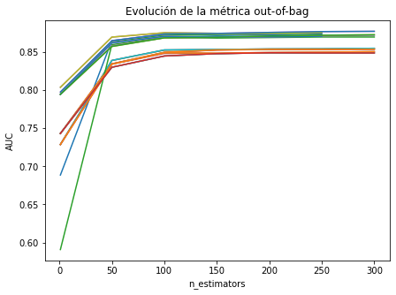

```python
fig, ax = plt.subplots(1, 1, figsize=(7,5))
history.set_index('n_estimators').plot(legend=False, ax=ax)
ax.set_ylabel('AUC');
ax.set_title('Evolución de la métrica out-of-bag');
```

### Búsqueda basada en validación cruzada

```python
from sklearn.model_selection import GridSearchCV

# Grid de valores sobre los que buscar
param_grid = {
             'max_depth'   : [3, 10, 20],
             'min_samples_leaf': [0.05, 0.1],
             'max_features': ['sqrt', 'log2'],
             'ccp_alpha': [0, 0.01]
            }
# Modelo
model = RandomForestClassifier(
            n_estimators = 1000,
            oob_score    = False,
            n_jobs       = -1,
            random_state = 123
        )


# Búsqueda por grid search con validación cruzada
start = pd.Timestamp.now()

grid = GridSearchCV(
        estimator  = model,
        param_grid = param_grid,
        scoring    = 'roc_auc',
        cv         = 5,
        refit      = False,
        verbose    = 0,
        return_train_score = True
       )

grid.fit(X = X, y = y)

end = pd.Timestamp.now()
print(f"Duración búsqueda: {end-start}")
```

```
Duración búsqueda: 0 days 00:08:10.084963
```

```python
# Resultados
resultados = pd.DataFrame(grid.cv_results_)
resultados.filter(regex = '(param.*|mean_t|std_t)') \
    .drop(columns = 'params') \
    .sort_values('mean_test_score', ascending = False)
```

|  | param_ccp_alpha | param_max_depth | param_max_features | param_min_samples_leaf | mean_test_score | std_test_score | mean_train_score | std_train_score |
| --- | --- | --- | --- | --- | --- | --- | --- | --- |
| 6 | 0 | 10 | log2 | 0.05 | 0.878148 | 0.002636 | 0.878743 | 0.000537 |
| 10 | 0 | 20 | log2 | 0.05 | 0.878148 | 0.002636 | 0.878743 | 0.000537 |
| 2 | 0 | 3 | log2 | 0.05 | 0.876852 | 0.002807 | 0.877345 | 0.000652 |
| 4 | 0 | 10 | sqrt | 0.05 | 0.876741 | 0.002586 | 0.877291 | 0.000556 |
| 8 | 0 | 20 | sqrt | 0.05 | 0.876741 | 0.002586 | 0.877291 | 0.000556 |
| 0 | 0 | 3 | sqrt | 0.05 | 0.875353 | 0.002981 | 0.875781 | 0.000502 |
| 22 | 0.01 | 20 | log2 | 0.05 | 0.874735 | 0.002897 | 0.875127 | 0.000503 |
| 18 | 0.01 | 10 | log2 | 0.05 | 0.874735 | 0.002897 | 0.875127 | 0.000503 |
| 14 | 0.01 | 3 | log2 | 0.05 | 0.873500 | 0.002960 | 0.873922 | 0.000638 |
| 20 | 0.01 | 20 | sqrt | 0.05 | 0.873017 | 0.002971 | 0.873407 | 0.000507 |
| 16 | 0.01 | 10 | sqrt | 0.05 | 0.873017 | 0.002971 | 0.873407 | 0.000507 |
| 12 | 0.01 | 3 | sqrt | 0.05 | 0.871871 | 0.003251 | 0.872314 | 0.000376 |
| 11 | 0 | 20 | log2 | 0.1 | 0.857833 | 0.002547 | 0.858329 | 0.000767 |
| 7 | 0 | 10 | log2 | 0.1 | 0.857833 | 0.002547 | 0.858329 | 0.000767 |
| 3 | 0 | 3 | log2 | 0.1 | 0.857781 | 0.002554 | 0.858269 | 0.000759 |
| 9 | 0 | 20 | sqrt | 0.1 | 0.857431 | 0.002756 | 0.857903 | 0.000716 |
| 5 | 0 | 10 | sqrt | 0.1 | 0.857431 | 0.002756 | 0.857903 | 0.000716 |
| 1 | 0 | 3 | sqrt | 0.1 | 0.857338 | 0.002769 | 0.857790 | 0.000709 |
| 19 | 0.01 | 10 | log2 | 0.1 | 0.855294 | 0.002501 | 0.855733 | 0.000834 |
| 23 | 0.01 | 20 | log2 | 0.1 | 0.855294 | 0.002501 | 0.855733 | 0.000834 |
| 15 | 0.01 | 3 | log2 | 0.1 | 0.855270 | 0.002514 | 0.855674 | 0.000779 |
| 17 | 0.01 | 10 | sqrt | 0.1 | 0.854539 | 0.002660 | 0.854884 | 0.000814 |
| 21 | 0.01 | 20 | sqrt | 0.1 | 0.854539 | 0.002660 | 0.854884 | 0.000814 |
| 13 | 0.01 | 3 | sqrt | 0.1 | 0.854433 | 0.002689 | 0.854813 | 0.000815 |

### Comparación de resultados

Los dos métodos obtienen errores de validación similares e identifican como mejor modelo el que tiene la configuración:

- param_ccp_alpha = 0
- param_max_depth = 10
- param_max_features = log2
- param_min_samples_leaf = 0.05

## Profiling

*Profiling* del código para identificar qué partes están requiriendo más tiempo de computo.

```python
# Grid de valores sobre los que buscar
param_grid = {
             'max_depth'   : [3, 10, 20],
             'min_samples_leaf': [0.05, 0.1],
             'max_features': ['sqrt', 'log2'],
             'ccp_alpha': [0, 0.01]
            }
# Modelo
model = RandomForestClassifier(
            n_estimators = 1000,
            oob_score    = True,
            n_jobs       = -1,
            random_state = 123
        )
```

```python
from line_profiler import LineProfiler

lp = LineProfiler()
lp_wrapper = lp(custom_gridsearch_RandomForestClassifier)
lp_wrapper(
    model                 = model,
    X                     = X,
    y                     = y,
    metric                = 'auc',
    param_grid            = param_grid,
    positive_class        = 1,
    score_tree_interval   = 50,
    stopping_rounds       = 4,
    stopping_tolerance    = 0.01,
    model_max_runtime_sec = None,
    max_models            = 5,
    max_runtime_sec       = None
)

lp.print_stats()
```

```
Refitting mode using the best found parameters and the whole data set:
 {'ccp_alpha': 0, 'max_depth': 3, 'max_features': 'sqrt', 'min_samples_leaf': 0.05, 'n_estimators': 250}
Timer unit: 1e-06 s

Total time: 38.3506 s
File: <ipython-input-1-501723037cfe>
Function: custom_gridsearch_RandomForestClassifier at line 259

Line #      Hits         Time  Per Hit   % Time  Line Contents
==============================================================
   259                                           def custom_gridsearch_RandomForestClassifier(
   260                                               model: RandomForestClassifier,
   261                                               X: Union[np.ndarray, pd.core.frame.DataFrame],
   262                                               y: np.ndarray,
   263                                               metric: str,
```

[output cut: 134 more lines]

```python
lp = LineProfiler()
lp_wrapper = lp(fit_RandomForest_early_stopping)
lp_wrapper(
    model                 = model,
    X                     = X,
    y                     = y,
    metric                = 'auc',
    positive_class        = 1,
    score_tree_interval   = 50,
    stopping_rounds       = 4,
    stopping_tolerance    = 0.01,
    max_runtime_sec       = None
)

lp.print_stats()
```

```
Timer unit: 1e-06 s

Total time: 6.00894 s
File: <ipython-input-1-501723037cfe>
Function: fit_RandomForest_early_stopping at line 128

Line #      Hits         Time  Per Hit   % Time  Line Contents
==============================================================
   128                                           def fit_RandomForest_early_stopping(
   129                                               model: Union[RandomForestClassifier, RandomForestRegressor],
   130                                               X: Union[np.ndarray, pd.core.frame.DataFrame],
   131                                               y: np.ndarray,
   132                                               metric: str,
   133                                               positive_class: int=1,
   134                                               score_tree_interval: int=None,
```

[output cut: 122 more lines]

## Información de sesión

```python
from sinfo import sinfo
sinfo()
```

[output not shown]

**¿Cómo citar este documento?**

Grid search de modelos Random Forest con out-of-bag error y early stopping por Joaquín Amat Rodrigo, disponible con licencia CC BY-NC-SA 4.0 en https://www.cienciadedatos.net/documentos/py36-grid-search-random-forest-out-of-bag-error-early-stopping.html

Este contenido, creado por Joaquín Amat Rodrigo, tiene licencia [Attribution-NonCommercial-ShareAlike 4.0 International](https://creativecommons.org/licenses/by-nc-sa/4.0/).

Se permite:

- Compartir: copiar y redistribuir el material en cualquier medio o formato.
- Adaptar: remezclar, transformar y crear a partir del material.

Bajo los siguientes términos:

- Atribución: Debes otorgar [el crédito adecuado](https://creativecommons.org/licenses/by-nc-sa/4.0/deed.es#ref-appropriate-credit), proporcionar un enlace a la licencia e [indicar si se realizaron cambios](https://creativecommons.org/licenses/by-nc-sa/4.0/deed.es#ref-indicate-changes). Puedes hacerlo de cualquier manera razonable, pero no de una forma que sugiera que el licenciante te respalda o respalda tu uso.
- NoComercial: No puedes utilizar el material para [fines comerciales](https://creativecommons.org/licenses/by-nc-sa/4.0/deed.es#ref-commercial-purposes).
- CompartirIgual: Si remezclas, transformas o creas a partir del material, debes distribuir tus contribuciones bajo la [misma licencia](https://creativecommons.org/licenses/by-nc-sa/4.0/deed.es#ref-same-license) que el original.